# A basic PLSR example using leaf-level specrta and leaf mass per area (LMA) data from several CONUS NEON sites

Shawn P. Serbin

### Overview

his is an [R Markdown](http://rmarkdown.rstudio.com) Notebook to illustrate how to conduct a basic model fit. This example shows you how to retrieve a dataset from the EcoSIS spectral database, choose the “optimal” number of plsr components, and fit a plsr model for leaf-mass area

### Installation

```r
list.of.packages <- c("readr","httr","pls","dplyr","reshape2")  # packages needed for script
# check for dependencies and install if needed
new.packages <- list.of.packages[!(list.of.packages %in% installed.packages()[,"Package"])]
if(length(new.packages)) install.packages(new.packages)
```

##### Load libraries

```r
# load libraries needed for script
library(readr)
library(dplyr)
library(reshape2)
library(ggplot2)
library(dplyr)
```

##### Prepare helpers

```r
# define function to grab PLSR model from GitHub
#devtools::source_gist("gist.github.com/christophergandrud/4466237")
source_GitHubData <-function(url, sep = ",", header = TRUE) {
  require(httr)
  request <- GET(url)
  stop_for_status(request)
  handle <- textConnection(content(request, as = 'text'))
  on.exit(close(handle))
  read.table(handle, sep = sep, header = header)
}

# not in
`%notin%` <- Negate(`%in%`)


# Script options
pls.options(plsralg = "oscorespls")
pls.options("plsralg")
```

$plsralg [1] “oscorespls”

```r
pls.options()$parallel
```

NULL

```r
# NULL
```

##### Setup temporary folder

```r
print(paste0("Output temporary directory: ",outdir))
```

[1] “Output temporary directory: /var/folders/xp/h3k9vf3n2jx181ts786_yjrn9c2gjq/T//RtmpsvOS65”

```r
setwd(outdir) # set working directory
getwd()  # check wd
```

[1] “/private/var/folders/xp/h3k9vf3n2jx181ts786_yjrn9c2gjq/T/RtmpsvOS65”

### Grab data from EcoSIS

##### URL: https://ecosis.org/package/fresh-leaf-spectra-to-estimate-lma-over-neon-domains-in-eastern-united-states

```r
print("**** Downloading Ecosis data ****")
```

[1] “**** Downloading Ecosis data ****”

```r
ecosis_id <- "5617da17-c925-49fb-b395-45a51291bd2d"  # NEON dataset
ecosis_file <- sprintf(
  "https://ecosis.org/api/package/%s/export?metadata=true",
  ecosis_id
)
message("Downloading data...")
dat_raw <- read_csv(ecosis_file)
message("Download complete!")
head(dat_raw)
```

| Affiliation | Common Name | Domain | Functional_type | LMA | Latin Genus | Latin Species | PI | Project | Sample_ID | USDA Symbol | 350 | 351 | 352 | 353 | 354 | 355 | 356 | 357 | 358 | 359 | 360 | 361 | 362 | 363 | 364 | 365 | 366 | 367 | 368 | … |
| --- | --- | --- | --- | --- | --- | --- | --- | --- | --- | --- | --- | --- | --- | --- | --- | --- | --- | --- | --- | --- | --- | --- | --- | --- | --- | --- | --- | --- | --- | --- |
| University of Wisconsin Madison | black walnut | D02 | broadleaf | 72.87 | Juglans | nigra | Philip A. Townsend | Foliar traits and terrestrial ecosystem variability across NEON domains | P0001 | JUNI | 0.254890 | 0.247660 | 0.240000 | 0.232030 | 0.222520 | 0.213290 | 0.206220 | 0.199290 | 0.193060 | 0.189720 | 0.186850 | 0.184010 | 0.184180 | 0.185040 | 0.185470 | 0.183320 | 0.179480 | 0.175360 | 0.170540 | … |
| University of Wisconsin Madison | black walnut | D02 | broadleaf | 72.87 | Juglans | nigra | Philip A. Townsend | Foliar traits and terrestrial ecosystem variability across NEON domains | L0001 | JUNI | 0.055946 | 0.064355 | 0.066696 | 0.067781 | 0.063824 | 0.061774 | 0.061223 | 0.056948 | 0.049936 | 0.048661 | 0.058246 | 0.050909 | 0.046395 | 0.054043 | 0.050124 | 0.051529 | 0.055467 | 0.040431 | 0.039243 | … |
| University of Wisconsin Madison | black walnut | D02 | broadleaf | 60.77 | Juglans | nigra | Philip A. Townsend | Foliar traits and terrestrial ecosystem variability across NEON domains | P0002 | JUNI | 0.250300 | 0.245670 | 0.239440 | 0.231470 | 0.222210 | 0.212960 | 0.205150 | 0.197180 | 0.189760 | 0.185420 | 0.181920 | 0.178750 | 0.177300 | 0.176560 | 0.176050 | 0.173810 | 0.170060 | 0.164960 | 0.158940 | … |
| University of Wisconsin Madison | black walnut | D02 | broadleaf | 60.77 | Juglans | nigra | Philip A. Townsend | Foliar traits and terrestrial ecosystem variability across NEON domains | L0002 | JUNI | 0.067230 | 0.070687 | 0.071606 | 0.063111 | 0.054258 | 0.054604 | 0.060045 | 0.057318 | 0.053878 | 0.053268 | 0.056435 | 0.052873 | 0.052184 | 0.057950 | 0.056944 | 0.052245 | 0.047148 | 0.045731 | 0.048567 | … |
| University of Wisconsin Madison | black walnut | D02 | broadleaf | 85.92 | Juglans | nigra | Philip A. Townsend | Foliar traits and terrestrial ecosystem variability across NEON domains | P0003 | JUNI | 0.242630 | 0.238740 | 0.234320 | 0.229850 | 0.223780 | 0.217380 | 0.211920 | 0.205420 | 0.198630 | 0.194180 | 0.190160 | 0.186320 | 0.185480 | 0.184930 | 0.183220 | 0.180930 | 0.177230 | 0.170210 | 0.163620 | … |
| University of Wisconsin Madison | black walnut | D02 | broadleaf | 85.92 | Juglans | nigra | Philip A. Townsend | Foliar traits and terrestrial ecosystem variability across NEON domains | L0003 | JUNI | 0.053395 | 0.054042 | 0.054579 | 0.051773 | 0.052081 | 0.054802 | 0.054821 | 0.043995 | 0.036599 | 0.041526 | 0.059207 | 0.050506 | 0.045114 | 0.056502 | 0.047939 | 0.041600 | 0.042760 | 0.042557 | 0.045046 | … |

```r
names(dat_raw)[1:40]
```

[1] “Affiliation” “Common Name” “Domain” “Functional_type” “LMA” “Latin Genus” “Latin Species”  
[8] “PI” “Project” “Sample_ID” “USDA Symbol” “350” “351” “352”  
[15] “353” “354” “355” “356” “357” “358” “359”  
[22] “360” “361” “362” “363” “364” “365” “366”  
[29] “367” “368” “369” “370” “371” “372” “373”  
[36] “374” “375” “376” “377” “378”

### Create PLSR dataset

```r
Start.wave <- 500
End.wave <- 2400
wv <- seq(Start.wave,End.wave,1)

spectra <- data.frame(dat_raw[,names(dat_raw) %in% wv])
names(spectra) <- c(paste0("Wave_",wv))
head(spectra)[1:6,1:10]
```

|  | Wave_500 | Wave_501 | Wave_502 | Wave_503 | Wave_504 | Wave_505 | Wave_506 | Wave_507 | Wave_508 | Wave_509 |
| --- | --- | --- | --- | --- | --- | --- | --- | --- | --- | --- |
| 1 | 0.044226 | 0.044605 | 0.044927 | 0.045473 | 0.046241 | 0.046878 | 0.047826 | 0.049090 | 0.050268 | 0.051525 |
| 2 | 0.046855 | 0.047601 | 0.047944 | 0.048478 | 0.049381 | 0.050235 | 0.051161 | 0.052191 | 0.053322 | 0.054357 |
| 3 | 0.043758 | 0.044171 | 0.044869 | 0.045465 | 0.045984 | 0.046933 | 0.047993 | 0.049090 | 0.050168 | 0.051441 |
| 4 | 0.041154 | 0.041603 | 0.042088 | 0.042408 | 0.042639 | 0.043260 | 0.044140 | 0.045058 | 0.045700 | 0.046476 |
| 5 | 0.037296 | 0.037944 | 0.038209 | 0.038677 | 0.039388 | 0.039948 | 0.040630 | 0.041501 | 0.042613 | 0.043731 |
| 6 | 0.043878 | 0.044257 | 0.044723 | 0.045295 | 0.045949 | 0.046575 | 0.047378 | 0.048357 | 0.049392 | 0.050387 |

```r
sample_info <- dat_raw[,names(dat_raw) %notin% seq(350,2500,1)]
head(sample_info)
```

| Affiliation | Common Name | Domain | Functional_type | LMA | Latin Genus | Latin Species | PI | Project | Sample_ID | USDA Symbol |
| --- | --- | --- | --- | --- | --- | --- | --- | --- | --- | --- |
| University of Wisconsin Madison | black walnut | D02 | broadleaf | 72.87 | Juglans | nigra | Philip A. Townsend | Foliar traits and terrestrial ecosystem variability across NEON domains | P0001 | JUNI |
| University of Wisconsin Madison | black walnut | D02 | broadleaf | 72.87 | Juglans | nigra | Philip A. Townsend | Foliar traits and terrestrial ecosystem variability across NEON domains | L0001 | JUNI |
| University of Wisconsin Madison | black walnut | D02 | broadleaf | 60.77 | Juglans | nigra | Philip A. Townsend | Foliar traits and terrestrial ecosystem variability across NEON domains | P0002 | JUNI |
| University of Wisconsin Madison | black walnut | D02 | broadleaf | 60.77 | Juglans | nigra | Philip A. Townsend | Foliar traits and terrestrial ecosystem variability across NEON domains | L0002 | JUNI |
| University of Wisconsin Madison | black walnut | D02 | broadleaf | 85.92 | Juglans | nigra | Philip A. Townsend | Foliar traits and terrestrial ecosystem variability across NEON domains | P0003 | JUNI |
| University of Wisconsin Madison | black walnut | D02 | broadleaf | 85.92 | Juglans | nigra | Philip A. Townsend | Foliar traits and terrestrial ecosystem variability across NEON domains | L0003 | JUNI |

```r
sample_info2 <- sample_info %>%
  select(Domain,Functional_type,Sample_ID,USDA_Species_Code=`USDA Symbol`,LMA_gDW_m2=LMA)
head(sample_info2)
```

| Domain | Functional_type | Sample_ID | USDA_Species_Code | LMA_gDW_m2 |
| --- | --- | --- | --- | --- |
| D02 | broadleaf | P0001 | JUNI | 72.87 |
| D02 | broadleaf | L0001 | JUNI | 72.87 |
| D02 | broadleaf | P0002 | JUNI | 60.77 |
| D02 | broadleaf | L0002 | JUNI | 60.77 |
| D02 | broadleaf | P0003 | JUNI | 85.92 |
| D02 | broadleaf | L0003 | JUNI | 85.92 |

```r
plsr_data <- data.frame(sample_info2,Spectra=I(as.matrix(spectra)))

inVar <- "LMA_gDW_m2"
```

### Plot the spectra

```r
cexaxis <- 1.5
cexlab <- 1.8
ylim <- 75

mean_spec <- colMeans(spectra[,which(names(spectra) %in% paste0("Wave_",wv))])
spectra_quantiles <- apply(spectra[,which(names(spectra) %in% paste0("Wave_",wv))],
                           2,quantile,na.rm=T,probs=c(0,0.025,0.05,0.5,0.95,0.975,1))

print("**** Plotting specrtal data ****")
```

[1] “**** Plotting specrtal data ****”

```r
par(mfrow=c(1,1), mar=c(4.5,5.7,0.3,0.4), oma=c(0.3,0.9,0.3,0.1)) # B, L, T, R
plot(wv,mean_spec,ylim=c(0,ylim),cex=0.00001, col="white",xlab="Wavelength (nm)",
     ylab="Reflectance (%)",cex.axis=cexaxis, cex.lab=cexlab)
polygon(c(wv ,rev(wv)),c(spectra_quantiles[5,]*100, rev(spectra_quantiles[3,]*100)),
        col="#99CC99",border=NA)
```

```r
lines(wv,mean_spec*100,lwd=3, lty=1, col="black")
lines(wv,spectra_quantiles[1,]*100,lwd=1.85, lty=3, col="grey40")
```

```r
lines(wv,spectra_quantiles[7,]*100,lwd=1.85, lty=3, col="grey40")
legend("topright",legend=c("Mean reflectance","Min/Max", "95% CI"),lty=c(1,3,1),
       lwd=c(3,3,15),col=c("black","grey40","#99CC99"),bty="n", cex=1.7)
```

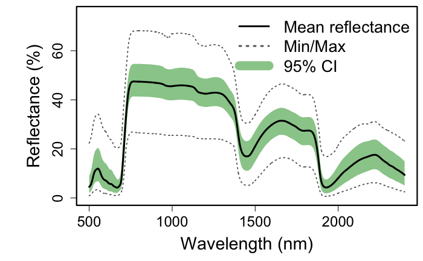

```r
box(lwd=2.2)
```

### Run Jackknife test to find number of components - simple example

```r
dims <- dim(plsr_data)
nComps <- 20
iterations <- 20
seg <- 5
prop <- 0.70
jk.out <- matrix(data=NA,nrow=iterations,ncol=nComps)
pls.options(parallel = parallel::detectCores()-1) # Use mclapply
print("*** Running jacknife permutation test.  Please hang tight, this can take awhile ***")
```

[1] "*** Running jacknife permutation test. Please hang tight, this can take awhile ***"

```r
start.time <- Sys.time()
for (i in 1:iterations) {
  rows <- sample(1:nrow(plsr_data),floor(prop*nrow(plsr_data)))
  sub.data <- plsr_data[rows,]
  plsr.out <- plsr(as.formula(paste(inVar,"~","Spectra")), scale=FALSE, center=TRUE, ncomp=nComps,
                   validation="CV", segments = seg, segment.type="interleaved", trace=FALSE, data=sub.data)
  resPRESS <- as.vector(plsr.out$validation$PRESS)
  jk.out[i,seq(plsr.out$validation$ncomp)]=resPRESS
}
end.time <- Sys.time()
end.time - start.time
```

Time difference of 1.966985 mins